# VAR Models

# Impulse Response Functions

Impulse response functions show how a shock to one variable affects the system over time.

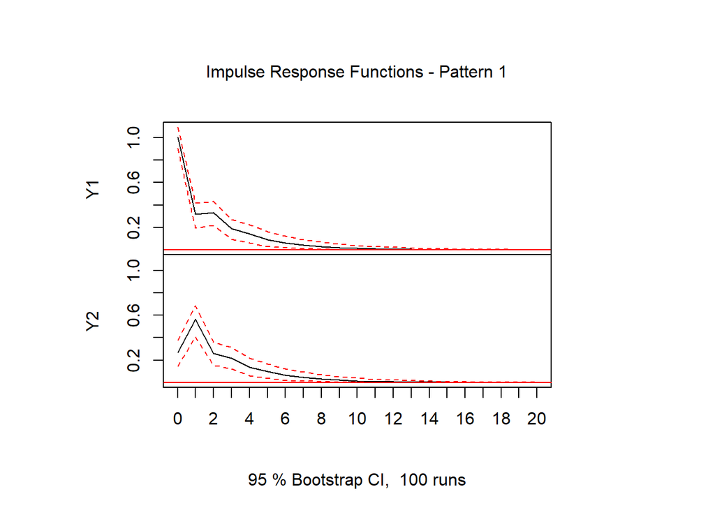

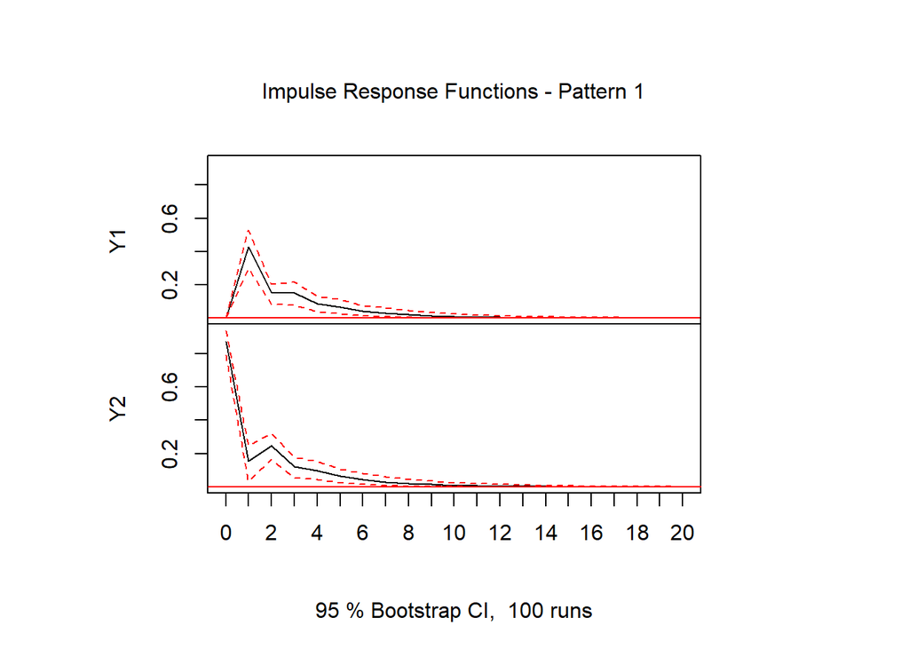

```r
# Convert to time series objects and estimate VAR
ts_data1 <- ts(data1[, c("Y1", "Y2")])
var_model <- VAR(ts_data1, p = 1, type = "const")

# Compute impulse response functions
irf_result <- irf(var_model, n.ahead = 20, boot = TRUE, ci = 0.95)

# Plot IRFs
plot(irf_result, main = "Impulse Response Functions - Pattern 1")
```

# Cross-Correlation Analysis

Understanding the lead-lag relationships between variables.

```r
# Cross-correlation function
par(mfrow = c(2, 2))

# Pattern 1: Positive cross-lagged
ccf_result1 <- ccf(data1$Y1, data1$Y2, main = "CCF: Pattern 1 (Positive Cross-lagged)")

# Pattern 2: Negative cross-lagged
ccf_result2 <- ccf(data2$Y1, data2$Y2, main = "CCF: Pattern 2 (Negative Cross-lagged)")

# Pattern 3: Granger causality
ccf_result3 <- ccf(data3$Y1, data3$Y2, main = "CCF: Pattern 3 (Granger Causality)")

# Pattern 4: Near unit root
ccf_result4 <- ccf(data4$Y1, data4$Y2, main = "CCF: Pattern 4 (Near Unit Root)")
```

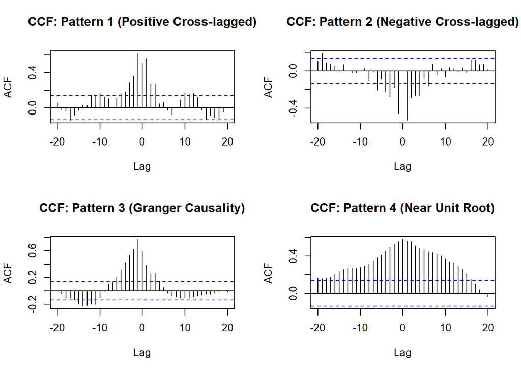

```r
par(mfrow = c(1, 1))
```

# Stability and Eigenvalues

The stability of a VAR model depends on the eigenvalues of the coefficient matrix.

```r
# Function to check stability
check_stability <- function(phi_matrix, pattern_name) {
  eigenvals <- eigen(phi_matrix)$values
  moduli <- Mod(eigenvals)
  max_modulus <- max(moduli)

  stable <- max_modulus < 1

  cat(paste("\n", pattern_name, ":\n"))
  cat(paste("Eigenvalues:", paste(round(eigenvals, 3), collapse = ", "), "\n"))
  cat(paste("Moduli:", paste(round(moduli, 3), collapse = ", "), "\n"))
  cat(paste("Max modulus:", round(max_modulus, 3), "\n"))
  cat(paste("Stable:", stable, "\n"))

  return(list(eigenvals = eigenvals, stable = stable))
}

# Check stability for all patterns
stability1 <- check_stability(phi_matrix_1, "Pattern 1 (Positive Cross-lagged)")
```

```
##
##  Pattern 1 (Positive Cross-lagged) :
## Eigenvalues: 0.7, -0.2
## Moduli: 0.7, 0.2
## Max modulus: 0.7
## Stable: TRUE
```

```r
stability2 <- check_stability(phi_matrix_2, "Pattern 2 (Negative Cross-lagged)")
```

```
##
##  Pattern 2 (Negative Cross-lagged) :
## Eigenvalues: 0.742, -0.242
## Moduli: 0.742, 0.242
## Max modulus: 0.742
## Stable: TRUE
```

```r
stability3 <- check_stability(phi_matrix_3, "Pattern 3 (Granger Causality)")
```

```
##
##  Pattern 3 (Granger Causality) :
## Eigenvalues: 0.7, 0.3
## Moduli: 0.7, 0.3
## Max modulus: 0.7
## Stable: TRUE
```

```r
stability4 <- check_stability(phi_matrix_4, "Pattern 4 (Near Unit Root)")
```

```
##
##  Pattern 4 (Near Unit Root) :
## Eigenvalues: 1, 0.85
## Moduli: 1, 0.85
## Max modulus: 1
## Stable: FALSE
```

# Summary of VAR Model Patterns

## Phase Plot Interpretations:

- **Spiral patterns**: Indicate oscillatory dynamics
- **Linear relationships**: Suggest strong contemporaneous correlation
- **Scattered patterns**: Indicate weak relationships or high noise
- **Expanding/contracting trajectories**: Related to system stability

## Practical Applications:

- **Economics**: GDP and inflation, interest rates and exchange rates
- **Finance**: Stock prices and trading volumes, different asset returns
- **Neuroscience**: Brain activity across different regions
- **Marketing**: Advertising spend and sales across channels
- **Climate**: Temperature and precipitation measurements

The choice of VAR model specification should be based on economic theory, statistical testing (Granger causality tests, lag selection criteria), and diagnostic checking of residuals.